# Modelos Lineares Generalizados

Fernando de Pol Mayer (LEG/UFPR)

Abril, 2016

# 1 Introdução

Análise de dados de nidificação de caranguejos-ferradura.

# 2 Pacotes necessários

```r
library(MASS)
library(hnp)
```

# 3 Dados

Importação e conferência dos dados.

```r
dados <- read.table("dados/crabs.txt", header = TRUE)
str(dados)
```

```
## 'data.frame':    173 obs. of  6 variables:
##  $ color : int  3 4 2 4 4 3 2 4 3 4 ...
##  $ spine : int  3 3 1 3 3 3 1 2 1 3 ...
##  $ width : num  28.3 22.5 26 24.8 26 23.8 26.5 24.7 23.7 25.6 ...
##  $ satell: int  8 0 9 0 4 0 0 0 0 0 ...
##  $ weight: int  3050 1550 2300 2100 2600 2100 2350 1900 1950 2150 ...
##  $ y     : int  1 0 1 0 1 0 0 0 0 0 ...
```

# 4 Análise descritiva e exploratória

Gráfico geral.

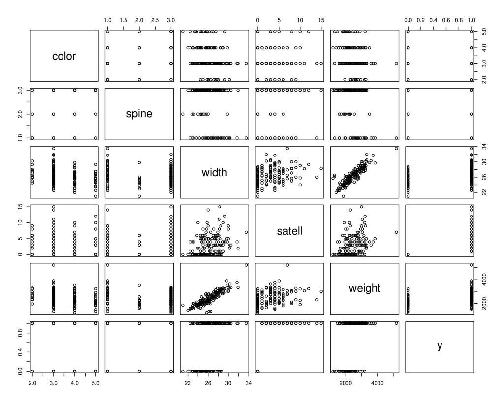

```r
plot(dados)
```

Histograma e boxplot do número de satélites.

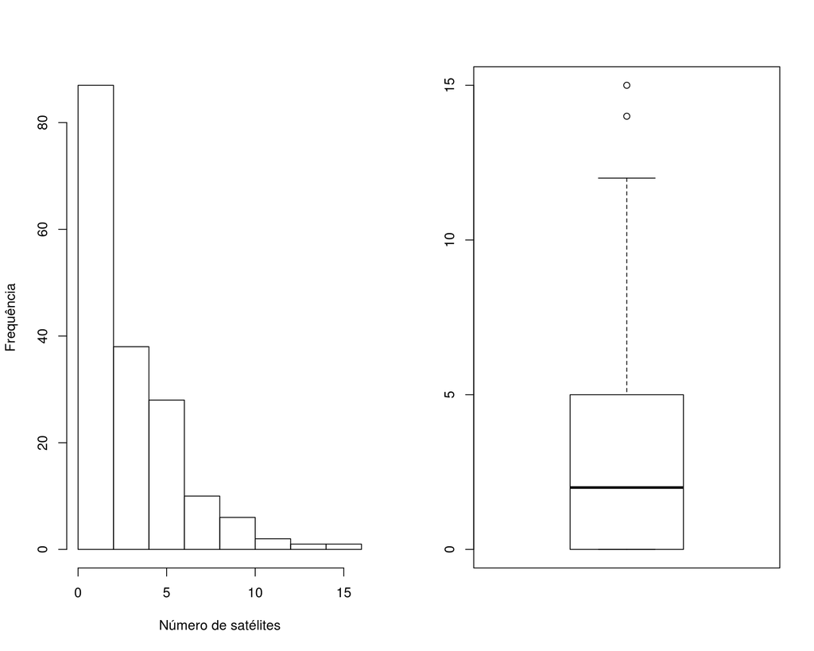

```r
par(mfrow = c(1, 2))
hist(dados$satell, xlab = "Número de satélites",
     ylab = "Frequência", main = "")
boxplot(dados$satell)
par(mfrow = c(1, 1))
```

Como o interesse é analisar a relação entre o número de satélites e o comprimento das fêmeas, vemos essa relação abaixo.

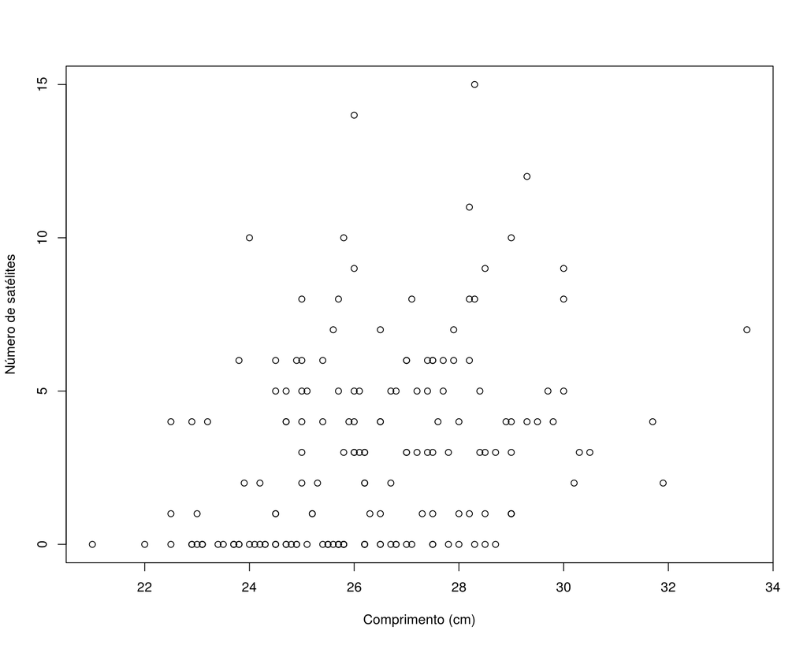

```r
plot(satell ~ width, data = dados,
     xlab = "Comprimento (cm)", ylab = "Número de satélites")
```

Como não há uma relação linear muito clara, podemos agregar os valores em uma **tabela de frequência** e analisar a relação a pertir dela.

```r
## Quebra de classes (reproduz as classes do livro)
quebra <- c(20.25, seq(23.25, 29.25, 1), 34.25)
## Identifica classes
classes <- cut(dados$width, breaks = quebra)
## Agrega os valores em uma tabela de frequência
fn <- function(x) cbind(length(x), sum(x), mean(x), var(x))
tab <- aggregate(satell ~ classes, data = dados, FUN = fn)
tab <- data.frame("classes" = tab[,1], tab[,2])
names(tab)[2:5] <- c("n", "nsatell", "med", "vari")
tab
```

```
##       classes  n nsatell      med      vari
## 1 (20.2,23.2] 14      14 1.000000  2.769231
## 2 (23.2,24.2] 14      20 1.428571  8.879121
## 3 (24.2,25.2] 28      67 2.392857  6.543651
## 4 (25.2,26.2] 39     105 2.692308 11.376518
## 5 (26.2,27.2] 22      63 2.863636  6.885281
## 6 (27.2,28.2] 24      93 3.875000  8.809783
## 7 (28.2,29.2] 18      71 3.944444 16.879085
## 8 (29.2,34.2] 14      72 5.142857  8.285714
```

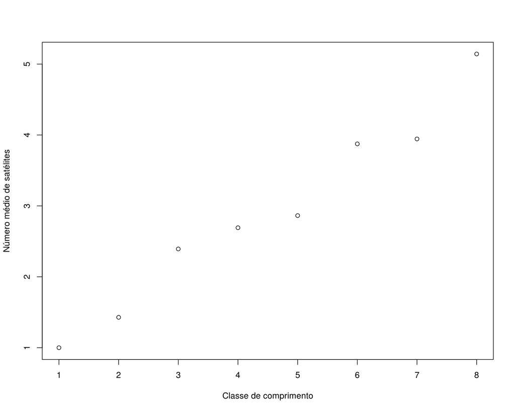

```r
plot(tab$med, xlab = "Classe de comprimento",
     ylab = "Número médio de satélites")
```

Agora a relação linear entre as duas variáveis fica bem mais clara. Vamos analisar também a relação entre a média e a variância do número de satélites em cada classe de comprimento.

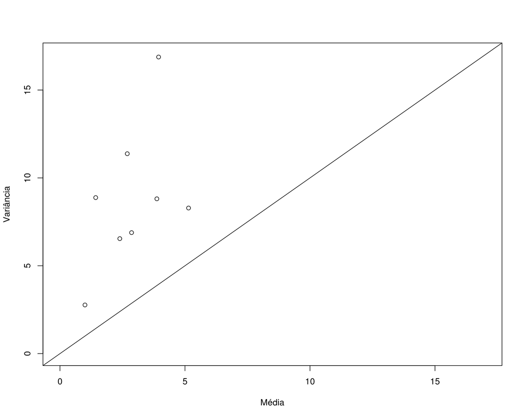

```r
plot(vari ~ med, data = tab, xlim = c(0, 17), ylim = c(0, 17),
     xlab = "Média", ylab = "Variância")
abline(a = 0, b = 1)
```

Podemos observar que a variância é sempre maior do que a média.

# 5 Modelos

## 5.1 Normal

Mesmo sabendo que não é adequado ajustar um modelo normal para contagens, vamos “forçar a barra” e analisar o resultado.

```r
m.norm <- glm(satell ~ width, data = dados,
              family = gaussian(link = "identity"))
```

Tabela de **Análise de Deviance**

```r
anova(m.norm, test = "Chisq")
```

```
## Analysis of Deviance Table
##
## Model: gaussian, link: identity
##
## Response: satell
##
## Terms added sequentially (first to last)
##
##
##       Df Deviance Resid. Df Resid. Dev Pr(>Chi)
## NULL                    172     1704.9
## width  1   196.96       171     1507.9 2.29e-06 ***
## ---
## Signif. codes:  0 '***' 0.001 '**' 0.01 '*' 0.05 '.' 0.1 ' ' 1
```

Coeficientes ajustados pelo modelo

```r
summary(m.norm)
```

```
##
## Call:
## glm(formula = satell ~ width, family = gaussian(link = "identity"),
##     data = dados)
##
## Deviance Residuals:
##     Min       1Q   Median       3Q      Max
## -4.1374  -2.2093  -0.7379   1.8921  11.2326
##
## Coefficients:
##             Estimate Std. Error t value Pr(>|t|)
## (Intercept) -10.4244     2.8324  -3.680 0.000312 ***
## width         0.5074     0.1074   4.726 4.76e-06 ***
## ---
## Signif. codes:  0 '***' 0.001 '**' 0.01 '*' 0.05 '.' 0.1 ' ' 1
##
## (Dispersion parameter for gaussian family taken to be 8.818196)
##
##     Null deviance: 1704.9  on 172  degrees of freedom
## Residual deviance: 1507.9  on 171  degrees of freedom
## AIC: 871.53
##
## Number of Fisher Scoring iterations: 2
```

Portanto o modelo é

$$\hat\mu = \hat\alpha + \hat\beta x = -10.424 + 0.507 x$$

Podemos agora **predizer** o valor esperado do número de satélites para qualquer comprimento. Por exemplo, se considerarmos o comprimento médio geral $x = 26.3$, então o número esperado de satélites seria

$$\hat\mu = \alpha + \beta x = -10.424 + 0.507(26.3) =
2.91$$

Como $\hat\beta = 0.507$, então o aumento de uma unidade no comprimento deve aumentar o número de satélites em exatamente $0.507$, ou seja,

$$\hat\mu = \alpha + \beta x = -10.424 + 0.507(27.3) =
3.42$$

que é exatamente igual a $2.91 + 0.507 = 3.42$.

Análise dos resíduos

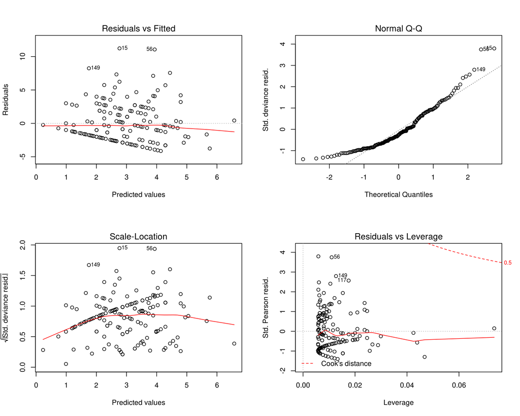

```r
par(mfrow = c(2, 2))
plot(m.norm)
par(mfrow = c(1, 1))
```

Gráfico de envelope simulado

```r
hnp(m.norm)
```

```
## Gaussian model (glm object)
```

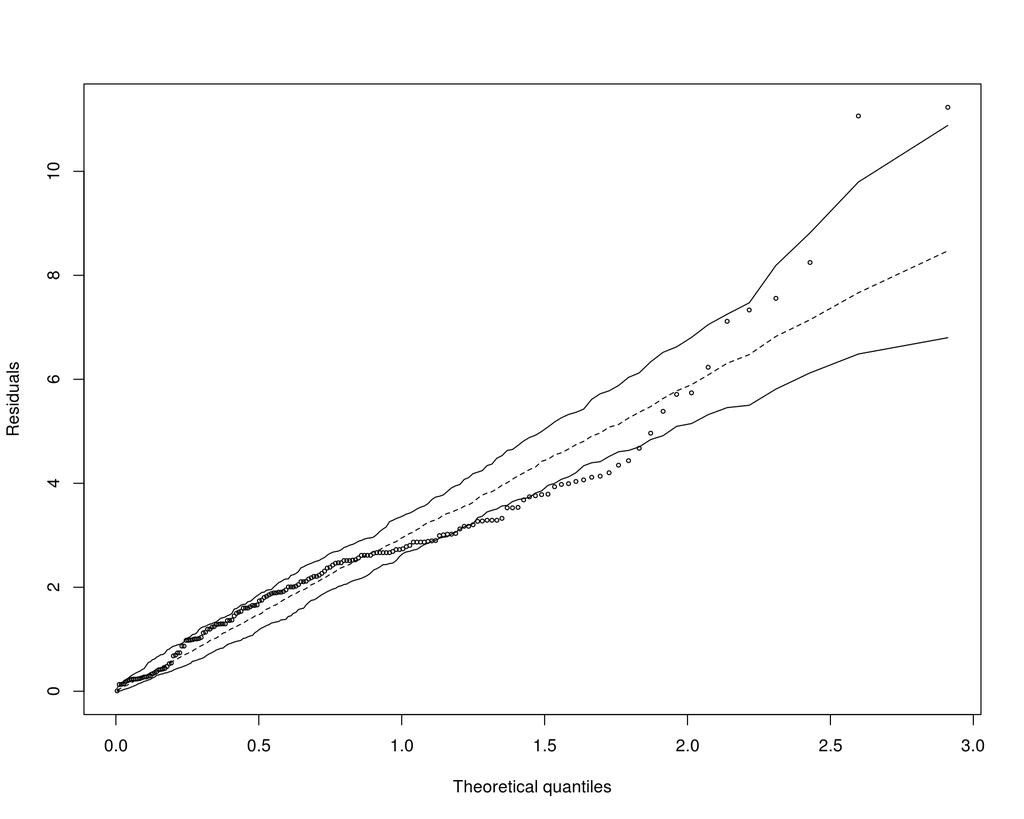

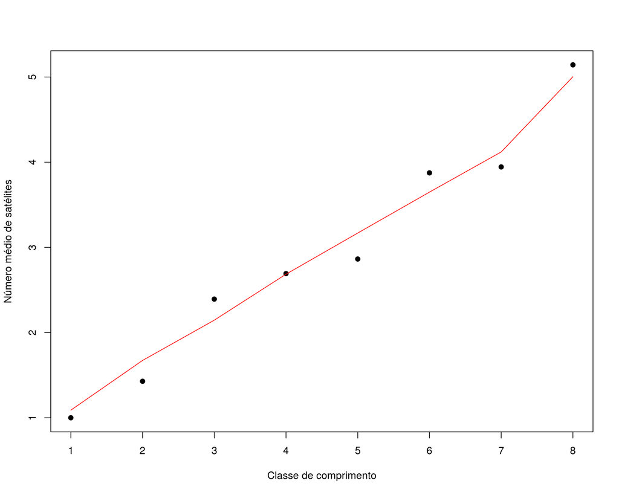

```r
pred.norm <- predict(m.norm)
tab.norm <- aggregate(pred.norm ~ classes, FUN = mean)
plot(tab$med, xlab = "Classe de comprimento",
     ylab = "Número médio de satélites", pch = 19)
lines(tab.norm$pred.norm, col = 2)
```

## 5.2 Poisson

### 5.2.1 Link log

A escolha mais natural para modelar contagens é o modelo Poisson.

A distribuição de Poisson possui média positiva $\mu$. Embora um MLG possa modelar uma média positiva usando o link identidade, é mais comum modelar o log da média.

Assim como o preditor linear $\alpha + \beta x$, o log da média pode assumir qualquer número real. O log da média é o **parâmetro natural** da distribuição Poisson na família exponencial, portanto o link log é o link **canônico** para um MLG Poisson.

Um MLG loglinear de Poisson assume uma distribuição de Poisson para $Y$ (**componente aleatório**) e usa a **função de ligação** (link) log. Portanto, um modelo loglinear de Poisson com uma variável explicativa $X$ (**componente sistemático**) é

$$\log \mu = \alpha + \beta x$$

Para este modelo, a média satisfaz então a seguinte relação

$$\hat\mu = \exp(\alpha + \beta x) = e^{\alpha}(e^{\beta})^{x}$$

Portanto, o aumento de 1 unidade em $x$, tem um **efeito multiplicativo** em $\mu$: a média em $x + 1$ é igual a média de $x$ **multiplicada** por $e^{\beta}$.

Inicialmente, vamos considerar então a função de ligação canônica (log) para ajustar o modelo Poisson.

```r
m.pois <- glm(satell ~ width, data = dados,
              family = poisson(link = "log"))
```

Tabela de **Análise de Deviance**

```r
anova(m.pois, test = "Chisq")
```

```
## Analysis of Deviance Table
##
## Model: poisson, link: log
##
## Response: satell
##
## Terms added sequentially (first to last)
##
##
##       Df Deviance Resid. Df Resid. Dev  Pr(>Chi)
## NULL                    172     632.79
## width  1   64.913       171     567.88 7.828e-16 ***
## ---
## Signif. codes:  0 '***' 0.001 '**' 0.01 '*' 0.05 '.' 0.1 ' ' 1
```

Coeficientes ajustados pelo modelo

```r
summary(m.pois)
```

```
##
## Call:
## glm(formula = satell ~ width, family = poisson(link = "log"),
##     data = dados)
##
## Deviance Residuals:
##     Min       1Q   Median       3Q      Max
## -2.8526  -1.9884  -0.4933   1.0970   4.9221
##
## Coefficients:
##             Estimate Std. Error z value Pr(>|z|)
## (Intercept) -3.30476    0.54224  -6.095  1.1e-09 ***
## width        0.16405    0.01997   8.216  < 2e-16 ***
## ---
## Signif. codes:  0 '***' 0.001 '**' 0.01 '*' 0.05 '.' 0.1 ' ' 1
##
## (Dispersion parameter for poisson family taken to be 1)
##
##     Null deviance: 632.79  on 172  degrees of freedom
## Residual deviance: 567.88  on 171  degrees of freedom
## AIC: 927.18
##
## Number of Fisher Scoring iterations: 6
```

Portanto o modelo é

$$\log \hat\mu = \hat\alpha + \hat\beta x = -3.305 + 0.164 x$$

O efeito $\hat\beta = 0.164$ é positivo, e indica a relação positiva que tinhamos observado. Assim, podemos *predizer* o número médio de satélites $\hat\mu$ para qualquer classe de comprimento. Por exemplo, o valor “ajustado” para a média de comprimento, $x = 26.3$ é

$$\hat\mu = \exp(\alpha + \beta x) = \exp{[-3.305 + 0.164(26.3)]} =
2.74$$

Para este modelo, $\exp{(\hat\beta)} = \exp{(0.164) = 1.18}$ é o **efeito multiplicativo** em $\hat\mu$ para o aumento de 1 unidade em $x$.

Por exemplo, o valor ajustado em $x = 27.3 = 26.3 + 1$ é

$$\hat\mu = \exp(\alpha + \beta x) = \exp{[-3.305 + 0.164(27.3)]} =
3.23$$

que é exatamente igual a $2.74 \times 1.18 = 3.23$. Ou seja, o aumento de 1 unidade em comprimento, resulta em um aumento de 18% no número de satélites.

Análise dos resíduos

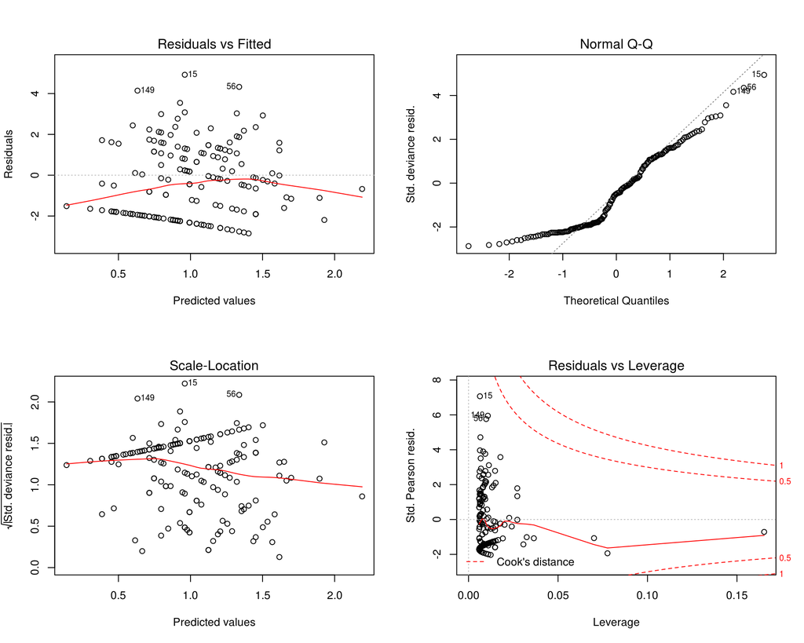

```r
par(mfrow = c(2, 2))
plot(m.pois)
par(mfrow = c(1, 1))
```

Gráfico de envelope simulado

```r
hnp(m.pois)
```

```
## Poisson model
```

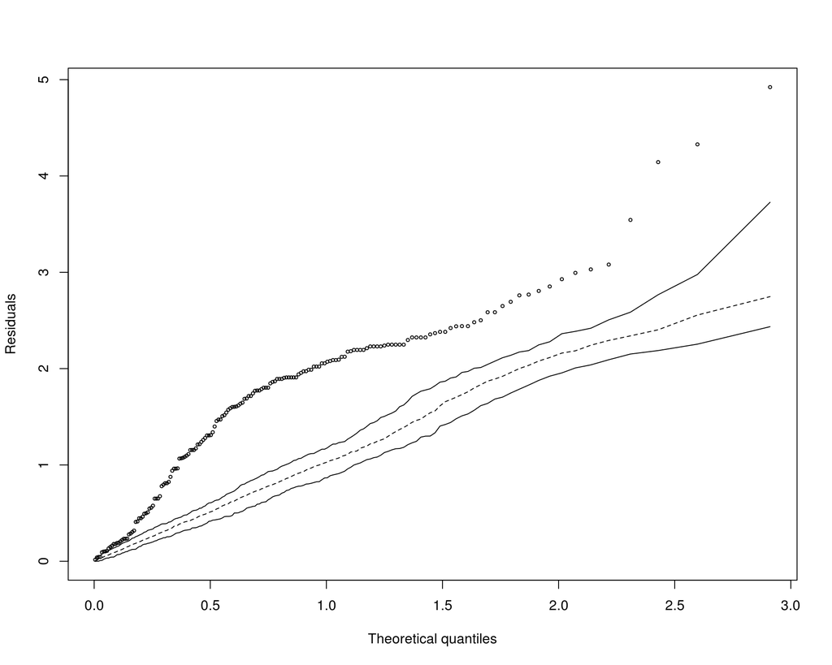

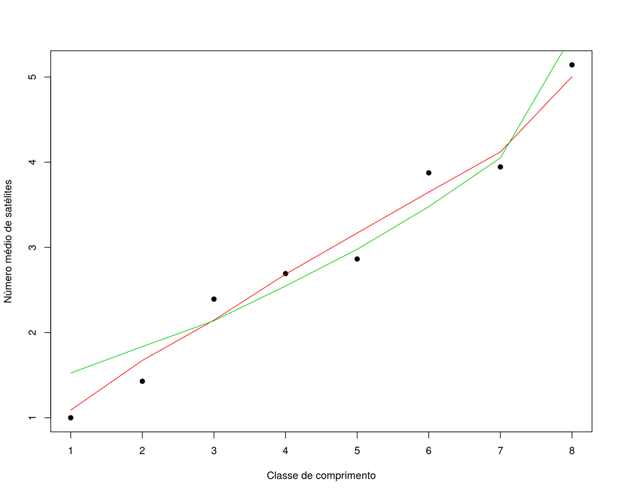

```r
pred.pois <- predict(m.pois, type = "response")
tab.pois <- aggregate(pred.pois ~ classes, FUN = mean)
plot(tab$med, xlab = "Classe de comprimento",
     ylab = "Número médio de satélites", pch = 19)
lines(tab.norm$pred.norm, col = 2)
lines(tab.pois$pred.pois, col = 3)
```

Como podemos observar, os resíduos estão longe de serem apropriados, e o gráfico de envelope simulado mostra que há um problema grave no ajuste do modelo.

### 5.2.2 Link identidade

Como vimos que a relação entre as duas variáveis é aproximadamente linear, isto sugere que uma função de ligação identidade pode ser utilizada.

como no caso do modelo normal. A grande diferença é que vamos considerar que a distribuição dos erros agora é Poisson.

```r
m.pois2 <- glm(satell ~ width, data = dados,
               family = poisson(link = "identity"),
               start = coef(m.pois))
```

Devido à problemas de convergência com o link identidade, é necessário especificar valores iniciais para o algoritmo de estimação. Nesse caso, os valores iniciais são os próprios coeficientes obtidos no modelo anterior com o link log.

Tabela de **Análise de Deviance**

```r
anova(m.pois2, test = "Chisq")
```

```
## Analysis of Deviance Table
##
## Model: poisson, link: identity
##
## Response: satell
##
## Terms added sequentially (first to last)
##
##
##       Df Deviance Resid. Df Resid. Dev  Pr(>Chi)
## NULL                    172     632.79
## width  1   75.083       171     557.71 < 2.2e-16 ***
## ---
## Signif. codes:  0 '***' 0.001 '**' 0.01 '*' 0.05 '.' 0.1 ' ' 1
```

Coeficientes ajustados pelo modelo

```r
summary(m.pois2)
```

```
##
## Call:
## glm(formula = satell ~ width, family = poisson(link = "identity"),
##     data = dados, start = coef(m.pois))
##
## Deviance Residuals:
##     Min       1Q   Median       3Q      Max
## -2.9113  -1.9598  -0.5405   1.0406   4.7988
##
## Coefficients:
##              Estimate Std. Error z value Pr(>|z|)
## (Intercept) -11.52547    0.67767  -17.01   <2e-16 ***
## width         0.54925    0.02968   18.50   <2e-16 ***
## ---
## Signif. codes:  0 '***' 0.001 '**' 0.01 '*' 0.05 '.' 0.1 ' ' 1
##
## (Dispersion parameter for poisson family taken to be 1)
##
##     Null deviance: 632.79  on 172  degrees of freedom
## Residual deviance: 557.71  on 171  degrees of freedom
## AIC: 917.01
##
## Number of Fisher Scoring iterations: 22
```

Portanto o modelo é

$$\hat\mu = \hat\alpha + \hat\beta x = -11.525 + 0.549 x$$

Como anteriormente, se fizermos a predição do número de satélites para o comprimento médio usando esse modelo, temos

$$\hat\mu = \alpha + \beta x = -11.525 + 0.549(26.3) =
2.913$$

Como a função de ligação é a identidade, então a relação é similar aquela de um modelo normal. Portanto, o aumento de 1 unidade de comprimento deve acarretar o aumento de $0.549$ unidades no número médio de satélites. De fato,

$$\hat\mu = \alpha + \beta x = -11.525 + 0.549(27.3) =
3.46$$

Análise dos resíduos

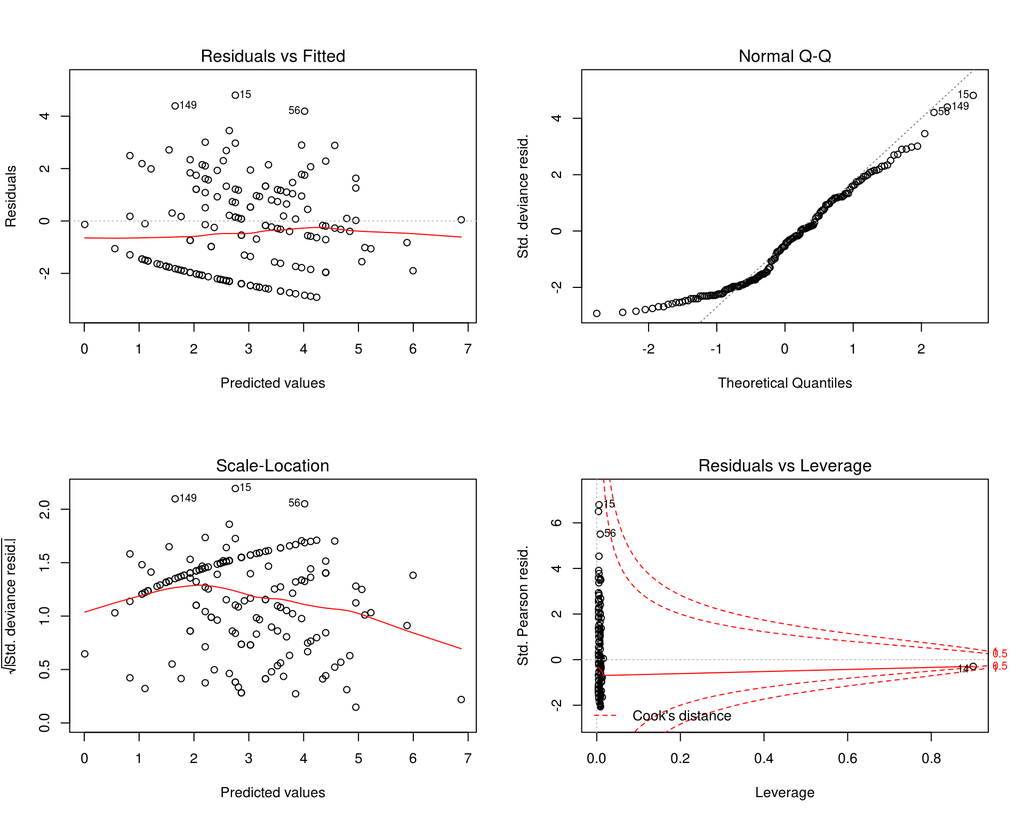

```r
par(mfrow = c(2, 2))
plot(m.pois2)
par(mfrow = c(1, 1))
```

Gráfico de envelope simulado

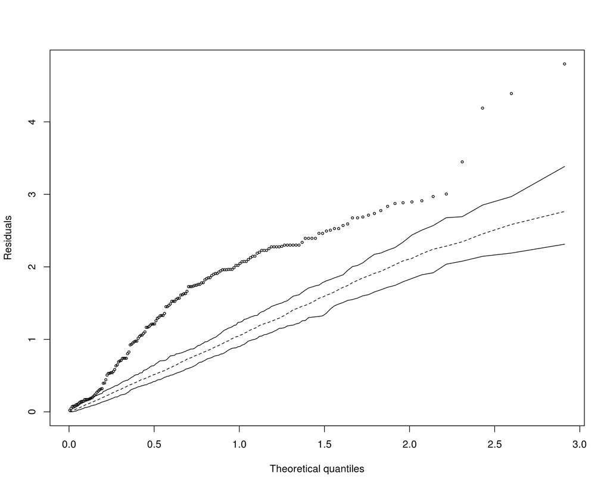

```r
dfun <- function(obj) resid(obj, type = "deviance")
sfun <- function(n, obj) as.numeric(simulate(obj)[,1])
ffun <- function(y.) glm(y. ~ width, data = dados,
                         family = poisson(link = "identity"),
                         start = coef(m.pois)) # aqui voce poe seu start
hnp(m.pois2, newclass=T, diagfun=dfun, simfun=sfun, fitfun=ffun)
```

Valores preditos.

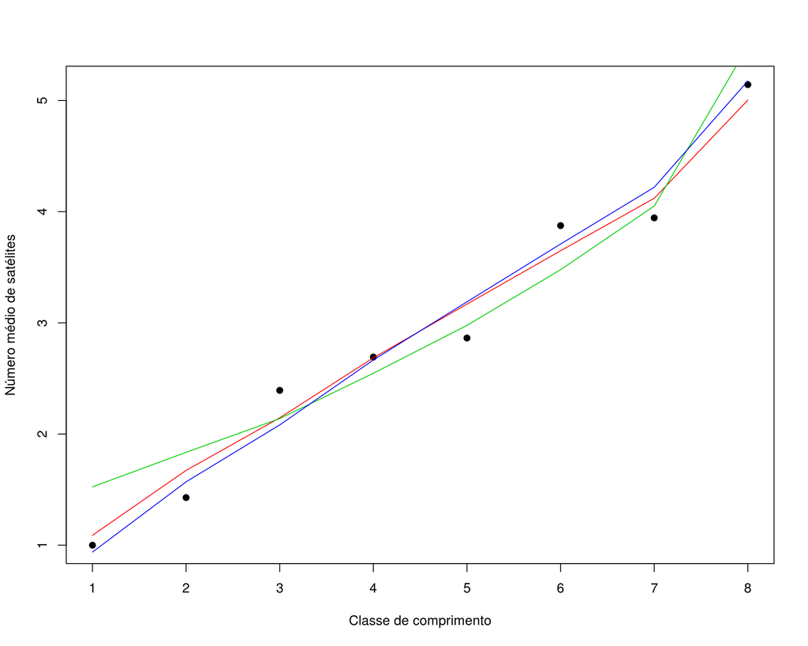

```r
pred.pois2 <- predict(m.pois2, type = "response")
tab.pois2 <- aggregate(pred.pois2 ~ classes, FUN = mean)
plot(tab$med, xlab = "Classe de comprimento",
     ylab = "Número médio de satélites", pch = 19)
lines(tab.norm$pred.norm, col = 2)
lines(tab.pois$pred.pois, col = 3)
lines(tab.pois2$pred.pois, col = 4)
```

## 5.3 Binomial negativo

Para este modelo, a média satisfaz então a seguinte relação

```r
m.bn <- glm.nb(satell ~ width, data = dados,
               link = "identity", start = coef(m.pois))
```

Tabela de **Análise de Deviance**

```r
anova(m.bn, test = "Chisq")
```

```
## Analysis of Deviance Table
##
## Model: Negative Binomial(0.9317), link: identity
##
## Response: satell
##
## Terms added sequentially (first to last)
##
##
##       Df Deviance Resid. Df Resid. Dev  Pr(>Chi)
## NULL                    172     216.51
## width  1   20.997       171     195.52 4.601e-06 ***
## ---
## Signif. codes:  0 '***' 0.001 '**' 0.01 '*' 0.05 '.' 0.1 ' ' 1
```

Coeficientes ajustados pelo modelo

```r
summary(m.bn)
```

```
##
## Call:
## glm.nb(formula = satell ~ width, data = dados, start = coef(m.pois),
##     link = "identity", init.theta = 0.9316967133)
##
## Deviance Residuals:
##     Min       1Q   Median       3Q      Max
## -1.7897  -1.4091  -0.2559   0.4522   2.1069
##
## Coefficients:
##              Estimate Std. Error z value Pr(>|z|)
## (Intercept) -11.63354    1.07112  -10.86   <2e-16 ***
## width         0.55398    0.05101   10.86   <2e-16 ***
## ---
## Signif. codes:  0 '***' 0.001 '**' 0.01 '*' 0.05 '.' 0.1 ' ' 1
##
## (Dispersion parameter for Negative Binomial(0.9317) family taken to be 1)
##
##     Null deviance: 216.51  on 172  degrees of freedom
## Residual deviance: 195.52  on 171  degrees of freedom
## AIC: 753.93
##
## Number of Fisher Scoring iterations: 1
##
##
##               Theta:  0.932
##           Std. Err.:  0.168
##
##  2 x log-likelihood:  -747.928
```

Gráfico de envelope simulado

```r
dfun <- function(obj) resid(obj, type = "deviance")
sfun <- function(n, obj) as.numeric(simulate(obj)[,1])
ffun <- function(y.) glm.nb(y. ~ width, data = dados,
                         link = "identity",
                         start = coef(m.pois)) # aqui voce poe seu start
hnp(m.bn, newclass=T, diagfun=dfun, simfun=sfun, fitfun=ffun)
```

[output not shown]

## 5.4 Comparação

```r
anova(m.norm, m.pois, m.pois2, m.bn, test = "F")
```

```
## Analysis of Deviance Table
##
## Model 1: satell ~ width
## Model 2: satell ~ width
## Model 3: satell ~ width
## Model 4: satell ~ width
##   Resid. Df Resid. Dev Df Deviance F Pr(>F)
## 1       171    1507.91
## 2       171     567.88  0   940.03
## 3       171     557.71  0    10.17
## 4       171     195.52  0   362.19
```